# Dynamic stacking for landmark prediction in new patients

A small R–Stan simulation and the relevant definition of PSIS-LOO

Published

October 2, 2026

## 1 Question and prediction target

We fit candidate longitudinal models to a set of patients with complete trajectories. For a *new* patient, we observe the baseline covariate and marker history through visit 3, then predict the marker separately at visits 4, 5, and 6. The prediction made for visit 6 does **not** use the patient’s outcomes at visits 4 or 5. In this simulation all visits are observed; censoring and irregular visits have not yet been modeled.

Let $\mathcal D_{-i}$ denote all training patients except patient $i$, $x_i$ the baseline group, $H_i=(y_{i0},\ldots,y_{i3})$, and $F_i=(y_{i4},y_{i5},y_{i6})$. For candidate model $k$, the cross-validated quantity needed to train the stacking weights is

$$p^{\mathrm{LM}}_{k,-i}(i,t)
=p_k(y_{it}\mid H_i,x_i,\mathcal D_{-i}),
\qquad t\in\{4,5,6\}. \tag{1}$$

The held-out patient is absent from model fitting, while their history is allowed to inform prediction at the landmark. Equation (1) is the score for the actual deployment task: predict a future measurement for a new patient whose earlier measurements are already available.

## 2 Relationship to Yao, Pirš, Vehtari, and Gelman

The paper’s longitudinal extension is in **§2.5** and its election back-testing example is in **§5.3**. Section 3 develops arguments about when input-dependent stacking may help. Section 6.1 briefly proposes leave-one-*cell*-out densities when the target is a new cell (Yao et al. 2022). Our study combines these ideas for a new patient observed through a fixed landmark. The combination and the formulas below are our extension; the paper does not establish a performance theorem for this clinical task.

| Aspect | Paper | This study |
| --- | --- | --- |
| Predictive unit | Usually an observation; §6.1 sketches a new cell | A patient is excluded as one cluster |
| Longitudinal score | One-unit or one-week-ahead prediction from earlier data | Fixed landmark, with three separate future horizons |
| Information from target unit | New-cell formula excludes the cell; longitudinal example uses past polling data | Held-out patient’s visits 0–3 are revealed at prediction time |
| Model weights | Hierarchical, input-dependent softmax weights | Two-model logistic weight using baseline group, horizon, and their interaction |
| Cross-validation computation | Often PSIS to avoid repeated model fits | Exact leave-one-patient-out refits and two patient-level PSIS approximations |
| Evaluation | Varies by application | Separate untouched patients, scored by conditional future log density |

The history affects each candidate’s predictive distribution through Gaussian conditioning of the patient-specific random intercept and slope. The *stacking weights themselves* currently use baseline group and horizon, but no summary of the observed marker history. Thus the ensemble is history-informed even though its gate does not directly vary with history. Adding a history summary to the gate is a possible next simulation condition.

## 3 Base models and exact leave-patient-out scoring

The synthetic outcome has a random intercept and slope. Group 1 has both a different linear trend and an upward bend after the landmark; group 0 has no bend. The linear candidate omits the bend. The curved candidate includes the bend but omits the group-specific linear trend. Both candidates are Gaussian mixed models fit using `base_model.stan`. Neither candidate exactly matches the data-generating mean.

For each patient $i$, we refit both candidates to $\mathcal D_{-i}$, then score the three future measurements using only $H_i$. Let $\theta_k$ be population parameters and $b_i$ the new patient’s random effects. For a set of visits $A$, define the marginal density

$$m_{ki}(A\mid\theta_k)
=\int p_k(y_{i,A}\mid b_i,x_i,\theta_k)
p_k(b_i\mid\theta_k)\,db_i. \tag{2}$$

Here the integral over $b_i$ is available analytically: the selected visits have a multivariate normal distribution with covariance from the random intercept, random slope, and measurement error. With $A_H=\{0,1,2,3\}$, the target in (1) is

$$p^{\mathrm{LM}}_{k,-i}(i,t)
=
\frac{
\int m_{ki}(A_H\cup\{t\}\mid\theta_k)
p_k(\theta_k\mid\mathcal D_{-i})\,d\theta_k
}{
\int m_{ki}(A_H\mid\theta_k)
p_k(\theta_k\mid\mathcal D_{-i})\,d\theta_k
}. \tag{3}$$

To see why (3) is exactly the conditional density in (1), start with the definition of conditional probability:

$$p_k(y_{it}\mid H_i,x_i,\mathcal D_{-i})
=
\frac{p_k(H_i,y_{it}\mid x_i,\mathcal D_{-i})}
{p_k(H_i\mid x_i,\mathcal D_{-i})}.$$

The numerator predicts the *joint* observations at visits $A_H\cup\{t\}$ from the other patients; the denominator predicts the history alone. Within either quantity, first integrate the new patient’s random effects as in (2), then average over the population posterior fitted to $\mathcal D_{-i}$. Those two averages are precisely the numerator and denominator of (3). The denominator matters because the observed history changes which population-parameter draws are plausible for this patient. Neither average includes the other post-landmark outcomes.

Bayes’ rule makes the same point in a second form:

$$p_k(\theta_k\mid \mathcal D_{-i},H_i,x_i)
=
\frac{m_{ki}(A_H\mid\theta_k)
p_k(\theta_k\mid\mathcal D_{-i})}
{\int m_{ki}(A_H\mid\vartheta)
p_k(\vartheta\mid\mathcal D_{-i})\,d\vartheta},
\qquad
p_k(y_{it}\mid H_i,x_i,\theta_k)
=\frac{m_{ki}(A_H\cup\{t\}\mid\theta_k)}
{m_{ki}(A_H\mid\theta_k)}.$$

Multiplying these expressions and integrating over $\theta_k$ cancels the two factors of $m_{ki}(A_H\mid\theta_k)$ inside the integral, leaving (3). This is also what the simulation code computes: it weights posterior draws by their history likelihood and averages each draw’s conditional Gaussian future density.

The code in `simulation.R` uses the second form. It also integrates out the held-out patient’s random effects; using a fitted random effect estimated from that patient’s full trajectory would leak future data.

## 4 What “PSIS-LOO” means for this task

Ordinary row-wise PSIS-LOO would hold out one measurement while leaving the same patient’s other future measurements in the model fit. That answers a different question. Calling `loo()` on one full-trajectory likelihood contribution per patient would instead estimate $p_k(H_i,F_i\mid\mathcal D_{-i})$, which is also **not** the conditional landmark target in (1). The required likelihood contribution is patient-level and marginal over that patient’s random effects.

Let $A_{\mathrm{all}}=\{0,\ldots,6\}$ and write $\ell^A_{ki}(\theta)=\log m_{ki}(A\mid\theta)$. Suppose $\theta_k^{(s)}$, $s=1,\ldots,S$, are draws from one full-data fit $p_k(\theta_k\mid\mathcal D)$. The following two routes reuse those draws to approximate the conditional target in (1). Some raw ratios can be very large: a draw that was rare under the full-data posterior may become important when patient $i$’s future is removed. PSIS stabilizes the largest ratios using a fitted Pareto tail, then normalizes the smoothed weights. Its Pareto $\widehat k$ and effective sample size describe whether the reweighted draws adequately represent the target posterior (Vehtari et al. 2024).

### 4.1 Remove the whole patient, then use the history

Importance sampling lets us estimate an expectation under one posterior using draws from another. For patient $i$, the full-data posterior has the factorization

$$p_k(\theta_k\mid\mathcal D)
\propto p_k(\theta_k\mid\mathcal D_{-i})
m_{ki}(A_{\mathrm{all}}\mid\theta_k).$$

Thus draws that make patient $i$’s complete trajectory especially likely are overrepresented relative to the leave-patient-out posterior. Dividing each draw’s weight by its *marginal full-trajectory likelihood* undoes that selection. Normalizing the weights makes them sum to one; the unknown proportionality constant cancels. The standard leave-one-*patient*-out raw importance ratio is

$$r^{\mathrm{LSO},(s)}_{ki}
\propto \frac{1}{m_{ki}(A_{\mathrm{all}}\mid
\theta_k^{(s)})}
=\exp\{-\ell^{\mathrm{all}}_{ki}
(\theta_k^{(s)})\}. \tag{4}$$

This first step targets $p_k(\theta_k\mid\mathcal D_{-i})$: **none** of patient $i$’s measurements remain. We then use the observed history $H_i$ to predict at the landmark. Let $\widetilde w_{ki,4}^{(s)}$ be the normalized, smoothed weights from (4), and let $q_{ki,t}^{(s)}=p_k(y_{it}\mid H_i,x_i,\theta_k^{(s)})$. Then equation (3) is estimated on the log scale by

$$\log\widehat p_{ki,t}^{(4)}
=\operatorname{LSE}_s\!\left(
\log\widetilde w_{ki,4}^{(s)}+\ell^H_{ki}(\theta_k^{(s)})
+\log q_{ki,t}^{(s)}\right)
-\operatorname{LSE}_s\!\left(
\log\widetilde w_{ki,4}^{(s)}+\ell^H_{ki}(\theta_k^{(s)})
\right),$$

where $\operatorname{LSE}$ is log-sum-exp. The history likelihood is required in **both** terms. Omitting it would average the future conditional densities over $p_k(\theta_k\mid\mathcal D_{-i})$ without updating the population posterior for the revealed history. In this route, PSIS acts on $1/m_{ki}(A_{\mathrm{all}}\mid\theta_k)$ *before* that history update.

### 4.2 Retain the history and remove only the future

The posterior needed immediately before prediction is $p_k(\theta_k\mid\mathcal D_{-i},H_i)$: it contains the other patients and patient $i$’s revealed history, but no post-landmark outcomes. Bayes’ rule and the factorization above give

$$p_k(\theta_k\mid\mathcal D_{-i},H_i)
\propto p_k(\theta_k\mid\mathcal D_{-i})
m_{ki}(A_H\mid\theta_k)
\propto p_k(\theta_k\mid\mathcal D)
\frac{m_{ki}(A_H\mid\theta_k)}
{m_{ki}(A_{\mathrm{all}}\mid\theta_k)}.$$

We can therefore target the landmark posterior in one step. Relative to the full-data posterior, the raw importance ratio is

$$r^{\mathrm{LM},(s)}_{ki}
\propto
\frac{m_{ki}(A_H\mid\theta_k^{(s)})}
{m_{ki}(A_{\mathrm{all}}\mid\theta_k^{(s)})}
=
\exp\{\ell^H_{ki}(\theta_k^{(s)})
-\ell^{\mathrm{all}}_{ki}(\theta_k^{(s)})\}.
\tag{5}$$

Because $m_{ki}(A_{\mathrm{all}}\mid\theta_k) =m_{ki}(A_H\mid\theta_k) p_k(F_i\mid H_i,x_i,\theta_k)$, ratio (5) is also $1/p_k(F_i\mid H_i,x_i,\theta_k)$. It undoes the contribution of **all three future measurements jointly**, while retaining the history. Removing only the particular $y_{it}$ being scored would leave the other future measurements in the posterior and leak information across horizons. After PSIS smooths and normalizes the ratios in (5), denote the weights by $\widetilde w_{ki,5}^{(s)}$. The estimate is a weighted average of the per-draw conditional density:

$$\widehat p^{\mathrm{LM,PSIS}}_{k,-i}(i,t)
=\sum_{s=1}^S \widetilde w_{ki,5}^{(s)}
\exp\{\ell^{H\cup\{t\}}_{ki}(\theta_k^{(s)})
-\ell^H_{ki}(\theta_k^{(s)})\}. \tag{6}$$

The two routes differ in *when* they incorporate the history:

|  | §4.1: whole-patient route, (4) | §4.2: direct landmark route, (5) |
| --- | --- | --- |
| Importance ratio | $1/m_{ki}(A_{\mathrm{all}}\mid\theta_k)$ | $m_{ki}(A_H\mid\theta_k)/m_{ki}(A_{\mathrm{all}}\mid\theta_k)$ |
| Posterior just after reweighting | Other patients only | Other patients plus patient $i$’s history |
| History update | Applied in the final ratio of weighted predictive densities | Already included in the importance ratio |
| Future score | Ratio of weighted joint and history densities | Weighted mean of $q_{ki,t}^{(s)}$ |
| Pareto diagnostic | Tail of whole-patient removal weights | Tail of future-removal weights |

Here is the exact algebra behind their common target. Before any Pareto smoothing, let $u_4^{(s)}=1/m_{ki}(A_{\mathrm{all}}\mid\theta_k^{(s)})$ and $u_5^{(s)}=m_{ki}(A_H\mid\theta_k^{(s)})u_4^{(s)}$. Then

$$\frac{\sum_s u_4^{(s)}m_{ki}(A_H\mid\theta_k^{(s)})q_{ki,t}^{(s)}}
{\sum_s u_4^{(s)}m_{ki}(A_H\mid\theta_k^{(s)})}
=\frac{\sum_s u_5^{(s)}q_{ki,t}^{(s)}}{\sum_s u_5^{(s)}}.$$

So the **unsmoothed estimates are identical for the same finite set of draws**, not merely in a large-sample limit. PSIS changes that: smoothing $u_4$ and then applying the history update generally differs from smoothing $u_5$ directly. The two Pareto $\widehat k$ diagnostics can also differ because they describe different ratio tails (Vehtari et al. 2024). Both PSIS estimates target (1), and the simulation compares them with exact subject-level refits. Section 4.2 can be described as patient-level leave-future-out importance sampling.

The implementation computes $\ell^{\mathrm{all}}$, $\ell^H$, and the conditional future log densities for *every* full-posterior draw, with the patient random effects integrated out. It passes the two log ratios separately to [`loo::psis()`](https://mc-stan.org/loo/reference/psis), and evaluates the scores on the log scale. The 200-draw cap applies only to test predictions and exact-refit predictive integration; the PSIS step uses all full-fit draws. Relative effective sample size is computed by MCMC chain for each ratio, then passed to `psis()`.

Concretely, for each candidate model and training patient, the R code:

1. Draws population parameters from the fit to **all** training patients.
2. Evaluates the marginal full-trajectory likelihood, the marginal history likelihood, and each horizon’s conditional future density at every draw. The patient’s random effects are integrated out of these quantities.
3. Forms either $-\ell^{\mathrm{all}}$ for (4) or $\ell^H-\ell^{\mathrm{all}}$ for (5), calls `loo::psis()` on those log ratios, and uses its normalized log weights in the corresponding predictive formula. The same weights serve all three future horizons.
4. Records Pareto $\widehat k$ and effective sample size, and compares both PSIS scores with the exact leave-patient-out refit scores.

```r
# Core of simulation.R's patient-level calculation:
ps4 <- loo::psis(-log_full, r_eff = r_eff_4)
ps5 <- loo::psis(log_history - log_full, r_eff = r_eff_5)
lw4 <- weights(ps4) # normalized log weights
lw5 <- weights(ps5)
log_score4 <- log_sum_exp(lw4 + log_history + log_conditional) -
  log_sum_exp(lw4 + log_history)
log_score5 <- log_sum_exp(lw5 + log_conditional)
```

The [`loo` diagnostic guidance](https://mc-stan.org/loo/reference/pareto-k-diagnostic.html) recommends exact refits or another validation design when the Pareto diagnostic is poor. With only 18 training patients, influential histories are plausible, so the exact refits provide a useful reference for checking both PSIS approximations.

## 5 Stacking objective and its scope

The two-model dynamic weight for the curved candidate is

$$w_{\mathrm{curved}}(x_i,h_t)
=\operatorname{logit}^{-1}
(\alpha_0+\alpha_1h_t+\alpha_2x_i+\alpha_3x_ih_t),
\qquad h_t=(t-3)/3. \tag{7}$$

The linear candidate has weight $1-w_{\mathrm{curved}}$. `stacking_weights.stan` puts a shrinkage prior on the three input effects. The constant version retains only $\alpha_0$. We fit the weights to the conditional out-of-subject predictive densities from (1), using the weighted log-mixture objective

$$\sum_{i=1}^n\frac{1}{3}
\sum_{t=4}^{6}
\log\!\left[
\sum_{k=1}^{2}w_k(x_i,h_t)
p^{\mathrm{LM}}_{k,-i}(i,t)
\right]. \tag{8}$$

The factor $1/3$ gives each patient total weight one. The three scores within a patient are dependent, so (8) is a **composite scoring objective**, not a joint likelihood for an entire future trajectory. The resulting mixture provides valid separate marginal predictive densities for each horizon, but it is not by itself a coherent joint distribution for visits 4–6. Evaluation therefore also reports the mean marginal log score, with the patient as the independent test unit.

## 6 Pilot results

The table reads the saved outputs from the default two-replicate run: 18 training patients and 60 untouched test patients per replicate. Higher mean log predictive density and lower RMSE are better.

Table 1: Performance on new test patients. All stacking fits use the same two candidate models.

| Method | Patients | Mean log density | RMSE |
| --- | --- | --- | --- |
| Constant stacking | 120 | -0.841 | 0.567 |
| Constant stacking, PSIS (4) | 120 | -0.841 | 0.567 |
| Constant stacking, PSIS (5) | 120 | -0.840 | 0.566 |
| Curved candidate | 120 | -0.924 | 0.596 |
| Dynamic stacking | 120 | -0.837 | 0.565 |
| Dynamic stacking, PSIS (4) | 120 | -0.837 | 0.565 |
| Dynamic stacking, PSIS (5) | 120 | -0.837 | 0.564 |
| Equal density mixture | 120 | -0.834 | 0.564 |
| Linear candidate | 120 | -0.870 | 0.570 |

The exact-refit stacking methods are labeled without a suffix. The four PSIS methods change only the training scores used to learn the weights; every method is evaluated on the same untouched test patients and the same full-data candidate posterior fits.

### 6.1 PSIS approximation against exact refits

The next table compares the candidate log predictive densities used to train stacking. Each difference is *PSIS minus exact refit* for one training patient and future visit. A smaller absolute difference is better; agreement does not by itself establish valid coverage or good out-of-sample performance.

Table 2: Difference between PSIS and exact patient refits in the training scores.

| Candidate | Formula | Mean absolute difference | Maximum absolute difference |
| --- | --- | --- | --- |
| linear | (4) | 0.019 | 0.176 |
| linear | (5) | 0.019 | 0.178 |
| curved | (4) | 0.023 | 0.143 |
| curved | (5) | 0.023 | 0.145 |

Pareto diagnostics are per **patient and candidate**, because each importance ratio removes that patient’s full trajectory from one candidate fit. There are three future scores per patient, but one importance-weight calculation for them all. In the table below, $k\ge 0.7$ is a simple caution flag; the sample-size-adjusted threshold in `loo` can be more stringent. A high $k$ means the corresponding PSIS estimate should not be treated as a reliable replacement for an exact refit (Vehtari et al. 2024).

Table 3: Patient-level PSIS diagnostics across candidate fits.

| Candidate | Formula | Patients with k >= 0.7 | Total patients | Maximum k | Minimum PSIS ESS |
| --- | --- | --- | --- | --- | --- |
| linear | (4) | 1 | 36 | 1.13 | 10.73 |
| linear | (5) | 0 | 36 | 0.64 | 150.36 |
| curved | (4) | 1 | 36 | 0.98 | 5.27 |
| curved | (5) | 1 | 36 | 0.76 | 46.47 |

The group-by-horizon comparison shows *why* mixtures are of interest here. A positive curved-minus-linear log-score difference favors the curved model. The right panel shows the fitted mean weight on that model, averaged over the two simulation replicates.

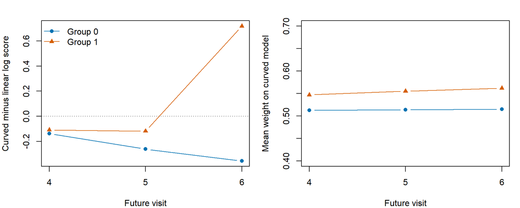

Figure 1: Local candidate contrast and learned curved-model weights by group and future visit.

The candidates do exchange relative strength, especially by the last horizon. These are descriptive results from two replicates, not evidence that one method generally dominates. The learned weight changes are modest, consistent with the small training sample and shrinkage. The patient-level predictions, training-score comparison, patient diagnostics, and group-by-horizon summary retain the numerical details.

## 7 Limits and next experiment

The simulation uses a continuous marker, a fixed landmark, complete follow-up, and independent Gaussian random intercepts and slopes. The cross-validation candidate fits use one short chain each; this does not establish convergence for every exact refit. The PSIS approximations use full-data fits with four chains and are checked against those refits. The next experiment should increase training sample size and replications and examine sampler diagnostics for all folds. Censoring, irregular visit times, and history-dependent weights require separate design choices before this can represent a real clinical prediction problem.

## 8 References

Vehtari, Aki, Daniel Simpson, Andrew Gelman, Yuling Yao, and Jonah Gabry. 2024. “Pareto Smoothed Importance Sampling.” *Journal of Machine Learning Research* 25 (72): 1–58. https://www.jmlr.org/papers/v25/19-556.html.

Yao, Yuling, Gregor Pirš, Aki Vehtari, and Andrew Gelman. 2022. “Bayesian Hierarchical Stacking: Some Models Are (Somewhere) Useful.” *Bayesian Analysis* 17 (4): 1043–71. https://doi.org/10.1214/21-BA1287.